# Comentario al conteo de población en un censo de período

¿Cómo puedo medir la superficie de un globo mientras alguien lo esta inflando? ¿Si compro el mismo helado en Alaska y en Río de Janeiro, tomo la misma cantidad de helado? ¿Cuantas personas habitan el pueblo que me asignaron censar en dos meses, si al mes de recorrerlo inauguran una fábrica que atrae residentes del pueblo vecino (los que fueron contados allí por un compañero censista)? Dentro de los tipos principales de censo (de hecho, de derecho, de registro), este se caracteriza por su definición en la unidad de análisis y su extensión en el tiempo, siendo un conteo de “película” (más que de “foto”).

En estos párrafos pensaremos qué implica este carácter en la estimación final, quizás el resultado más importante para un censo: ¿Cuántos somos?. Lo referido a la distribución de atributos es más complejo, y daremos algunos pautas de su abordaje. Hay preguntas adicionales también interesantes: ¿cuán sensible es el conteo a las formas posibles de dinámica y relevamiento?, ¿dónde es conveniente colocar en el tiempo la estimación final?, ¿tiene varianza esta estimacion? A este problema se enfrentan aquellos que planifican un censo de derecho, y creemos que el análisis demográfico puede aportar algunos elementos más, sin pretender dar verdades finales al respecto dada la complejidad práctica del asunto.

Suponiendo un censo de que se prolonga $d$ años en una población homogénea a lo largo de un territorio, se define una función de relevamiento $R_{d}\sim f(t)$ en $d\geq t \geq0$, la cual indica de qué forma se cubre el territorio durante $d$, cumpliendo que $\int_{0}^{d}{f(t) dt}=1$.

Sin pretender abarcar las infinitas posibilidades, podemos suponer cuatro tipos de relevamiento según en qué momento se concentran los mayores esfuerzos de relevamiento (“ritmo” de la película):

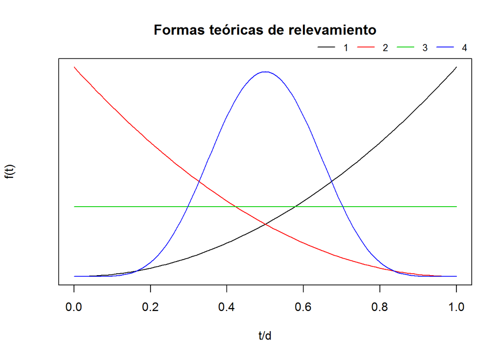

De esta manera, si la población cada momento es $N_{t}$ y el conteo censal es una función de t (varaible aleatoria), este puede ser considerado la esperanza matemática:

$E(P)=\int_{0}^{d}{{}_{ }{}^{ }N_{t}}f(t) dt$

La cual es una porción de la exposición del período $P^*=\int_{0}^{d}{N_{t}dt}$ (“conteo ideal”). La varianza de P se puede obtener por diferencia de momentos.  
La segunda cuestión relevante es donde colocar la estimación final. La respuesta adecuada sería en aquel valor $t^*$ siendo $(d\geq t^* \geq 0)$ tal que $P={}_{ }{}^{ }N_{t}$.

Para darle números a estas relaciones, supongamos un crecimiento exponencial constante de una población de 100 personas en el momento 0 (el nivel no influye), con escenarios de tasa anual $r=0.01$ (aceptable en poblaciones nacionales en una ventana menor a un año) y $r=0.1$ (situación extraordinaria) y un horizonte de relevamiento de $d=0.25$ o $d=0.75$ (9 meses, promedio latinoamericano), la implicancia de cada $f(t)$ se puede ver en la siguiente tabla:

Escenarios teóricos de relevamiento

| $r$ | $d$ | $R_{d}$ | $E(P)$ | $Ls(IC95)$ | $CV$ | $t^*/d$ |
| --- | --- | --- | --- | --- | --- | --- |
| 0.01 | 0.25 | 1 | 100.19 | 100.28 | 0.0 | 0.75 |
| 0.01 | 0.25 | 2 | 100.11 | 100.25 | 0.1 | 0.45 |
| 0.01 | 0.25 | 3 | 100.13 | 100.27 | 0.1 | 0.50 |
| 0.01 | 0.25 | 4 | 100.21 | 100.27 | 0.0 | 0.85 |
| 0.01 | 0.75 | 1 | 100.56 | 100.85 | 0.1 | 0.75 |
| 0.01 | 0.75 | 2 | 100.24 | 100.60 | 0.2 | 0.32 |
| 0.01 | 0.75 | 3 | 100.38 | 100.80 | 0.2 | 0.50 |
| 0.01 | 0.75 | 4 | 100.49 | 100.73 | 0.1 | 0.66 |
| 0.10 | 0.25 | 1 | 101.89 | 102.86 | 0.5 | 0.75 |
| 0.10 | 0.25 | 2 | 101.14 | 102.56 | 0.7 | 0.45 |
| 0.10 | 0.25 | 3 | 101.26 | 102.69 | 0.7 | 0.50 |
| 0.10 | 0.25 | 4 | 102.15 | 102.78 | 0.3 | 0.85 |
| 0.10 | 0.75 | 1 | 105.80 | 108.79 | 1.4 | 0.75 |
| 0.10 | 0.75 | 2 | 102.46 | 106.13 | 1.8 | 0.32 |
| 0.10 | 0.75 | 3 | 103.85 | 108.25 | 2.2 | 0.50 |
| 0.10 | 0.75 | 4 | 105.06 | 107.57 | 1.2 | 0.66 |

Como principales conclusiones podemos decir que:

- Extender el período aumenta el conteo final, y esta diferencia depende de r.
- la varianza aumenta ante un crecimiento mayor sobre todo.
- El único escenario que justifica colocar la estimación a mitad de período es cuando el relevamiento es uniforme.

Mencionando un caso real, el Censo de derecho de 2005 en Colombia se planificó un $d=0.8$, para el cual se agruparon áreas menores según similitud de dinámica demográfica reciente, concentrando en el mes central el 65% de la población total, la cual se caracterizaba por una dinámica menos estable, y con un 30% en los últimos 39 días. Esta estrategia tiene como fin principal la captación de una estructura de atributos. Con estrategias sectorizadas de este tipo, se puede pensar en el mismo ejercicio anterior pero con dos subpoblaciones, cada una con su $R_{d}$, para luego llevar cada estimación desde su respectivo $t^*$ a un punto en común utilizando cada $r$ (en función de una estimación censal anterior).

El motivo de estos párrafos fue poner sobre la mesa qué contamos en un censo de derecho. Quedan múltiples aspectos por estudiar.